# Análisis de Datos I Tarea 10

# Librerias

A continuación se muestran la librerías con las que se estará trabajando.

```r
library(traineR)
library(caret)
library(dplyr)
library(MASS)
```

# Ejercicio 2

# Ejercicio 3

## Carga de datos

Inicialmente se procede cargando los datos que se utilizarán en el *Análisis Discriminante Lineal*.

```r
Ejemplo_AD <- read.csv("Ejemplo_AD.csv", sep = ";", dec='.', header=T,
                       row.names = 1, stringsAsFactors = T)

Tumores <- read.csv("tumores.csv", sep = ",", dec='.', header=T,
                       row.names = 1, stringsAsFactors = T)
```

## Partición de los datos

A continuación se procede con la partición de los datos en 2 sets, uno de entrenamiento con el 70% de los datos, y otro con un 30% para las pruebas.

```r
# Se fija la semilla para reproducibilidad.
set.seed(2901)

# Se obtiene los indices para el primer set de train.
indices <- createDataPartition(Ejemplo_AD[,6], p = .70,list = F)

# Se obtiene la muestra para aprendizaje y prueba.
Ejemplo_AD_train <- Ejemplo_AD[indices,]
Ejemplo_AD_test <- Ejemplo_AD[-indices,]
```

Ahora se repite el proceso para el segundo set de datos.

```r
# Se fija la semilla para reproducibilidad.
set.seed(2901)

# Se obtiene los indices para el primer set de train.
indices <- createDataPartition(Tumores[,17], p = .70,list = F)

# Se obtiene la muestra para aprendizaje y prueba.
Tumores_train <- Tumores[indices,]
Tumores_test <- Tumores[-indices,]
```

## Creación del algoritmo con base en el *pseudo codigo*.

Ahora se procede con la creación de una función llamada `ADL` la cual recibe un dataframe (`datos`) con la información de entrenamiento.

```r
ADL <- function(datos){
  # Se convierte la información recibida en un matriz para mejorar la forma en
  # que se trabaja con los datos.
  X <- data.matrix(datos)

  # Se obtiene el indice la la variable categórica que está al final.
  indice <- ncol(datos)

  # Se divide la información.
  X1 <- X[,-indice]

  # Se obtiene las modalidades de la variable categórica.
  modalidades <- as.vector(unique(datos[,indice]))

  # Se obtiene el numero de modalidades que será útil.
  n_mod <- length(modalidades)

  # Se inicializa la matriz que contendrá los códigos disyuntivos.
  X2 <- matrix(, nrow = nrow(X), ncol = 0)

  # Se recorre cada modalidad y se crean los códigos disyuntivos respectivos.
  for(i in 1:n_mod){
    X2 <- cbind(X2, as.numeric(datos[indice] == modalidades[i]))
  }

  # Se crea la matriz diagonal D_g.
  D_g <- table(datos[,indice], datos[,indice])

  # Se obtiene la matriz inversa.
  Inv_D_g <- solve(D_g)

  # Se obtiene la matriz G con los centros de gravedad.
  G <- Inv_D_g %*% t(X2) %*% X1

  # Se crea la matriz de la cual se obtendrán los factores discriminantes.
  FD_matriz <- solve(t(X1) %*% X1) %*% t(G) %*% D_g %*% G


  # Se obtiene los valores y vectores propios de la matriz anterior.
  eigen <- eigen(FD_matriz)

  # Se crea una lista que contendrá toda la información del modelo para la
  # clásificación de nuevos individuos.
  resultado <- list(Re(eigen[[1]][1:(n_mod-1)]), Re(eigen[[2]][,1:(n_mod-1)]),G)
  names(resultado) <- c("Valores propios", "Factores dicriminantes",
                        "Matriz de CGs")

  return(resultado)
}
```

## Pruebas con la base *Ejemplo_AD*

```r
resultado <- ADL(Ejemplo_AD_train)
resultado
```

```
## $`Valores propios`
## [1] 0.9952515 0.7653630
##
## $`Factores dicriminantes`
##             [,1]        [,2]
## [1,] -0.27231057  0.15635992
## [2,] -0.04373598 -0.07289682
## [3,] -0.47381610  0.31289403
## [4,]  0.82218860 -0.93270597
## [5,] -0.15309580 -0.04893383
##
## $`Matriz de CGs`
##         RT1      RT2       RT3       RT4      RT5
## A 11.142857 6.185714 2.9428571 0.2857143 20.58571
## B  7.228571 5.485714 1.8285714 0.4285714 20.97143
## C  4.000000 6.242857 0.9428571 1.0285714 21.12857
```

Ahora se procede a obtener las coordenadas y a graficar.

```r
z1 <- data.matrix(Ejemplo_AD_train[,-6]) %*% resultado[[2]][,1]
z2 <- data.matrix(Ejemplo_AD_train[,-6]) %*% resultado[[2]][,2]
coordenadas <- data.frame(z1, z2)
head(coordenadas)
```

```
##           z1         z2
## A1 -7.467266  0.3419385
## B1 -5.890088 -1.6350419
## A2 -7.103186  1.3406749
## B2 -5.937315  0.4688522
## C2 -3.462590 -0.9231316
## C3 -4.460751 -2.2514080
```

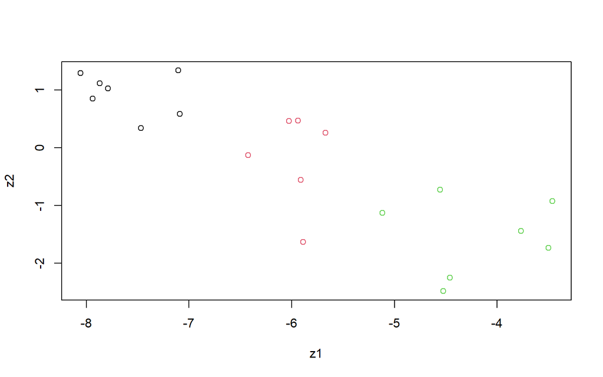

```r
plot(coordenadas, col = as.numeric(Ejemplo_AD_train[,6]))
```

```r
model <- lda(Ejemplo_AD_train[,1:5], Ejemplo_AD_train[,6])
model
```

```
## Call:
## lda(Ejemplo_AD_train[, 1:5], Ejemplo_AD_train[, 6])
##
## Prior probabilities of groups:
##         A         B         C
## 0.3333333 0.3333333 0.3333333
##
## Group means:
##         RT1      RT2       RT3       RT4      RT5
## A 11.142857 6.185714 2.9428571 0.2857143 20.58571
## B  7.228571 5.485714 1.8285714 0.4285714 20.97143
## C  4.000000 6.242857 0.9428571 1.0285714 21.12857
##
## Coefficients of linear discriminants:
##             LD1         LD2
## RT1 -0.64978726  0.34348261
## RT2 -0.03092065  0.20736978
## RT3 -1.15680956 -0.71918814
## RT4  2.30118918  1.34704442
## RT5 -0.26127867 -0.02082875
##
## Proportion of trace:
##    LD1    LD2
## 0.9955 0.0045
```

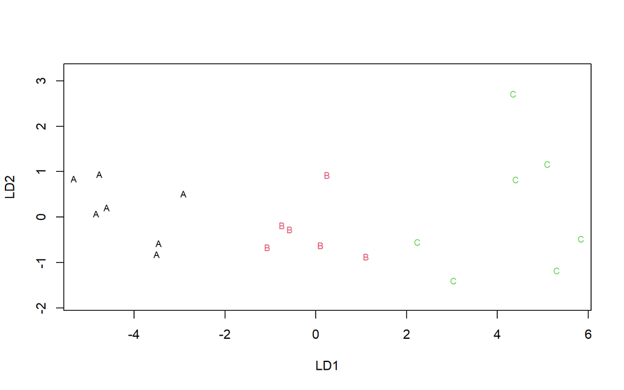

```r
plot(model, col = as.numeric(Ejemplo_AD_train[,6]))
```